# 08_draft_report

Jiayi Lily Ma (jm4303), Lina Tian (yt2511), and Wen Ding (wd2288)

5/10/2019

# Part 1: Paper’s code

**The models they used:**

- base model reg0 is $y = \beta_0 + \beta_1y_{t-1} + \beta_2y_{t-12}$
- Trend model reg1 is $y = \beta_0 + \beta_1y_{t-1} + \beta_2y_{t-12} + \beta_3suvs + \beta_4insurance$

**The out of sample forcasting method they used:**

- Rolling window forecast: Starting from the 18th month in the data, they use all the previous months to train a model and predict the next month.
- function to use in oosf.R: OutOfSampleForecast12()

## 1.1 Create function for model and evaluation using their out of sample forecast functions

```r
#paper's code wrapped in function format
#data input should have date format mm/dd/y
#data columns should be: date, sales, suvs, insurance
getModelandEvaluation <- function(data, print=1, plot_title = "log(sales) over time") {
  zooObj <- zoo(data[,-1], as.Date(data[,1]))
  y <- log(zooObj$sales)
  x <- zooObj[, c("suvs", "insurance")]

  reg0 <- dyn$lm(y~lag(y,-1) + lag(y, -12))
  reg1 <- dyn$lm(y~lag(y,-1)+lag(y,-12)+suvs+insurance,data=data)

  if(print == 1){
    print("Summary of base model")
    print(summary(reg0))
    print("Summary of trend model")
    print(summary(reg1))
  }

  z <- OutOfSampleForecast12(y,x,17)
  print(MaeReport(z, plot_title = plot_title))
}
```

## 1.2 Paper’s code, paper’s data

```
## [1] "Summary of base model"
##
## Call:
## lm(formula = dyn(y ~ lag(y, -1) + lag(y, -12)))
##
## Residuals:
##       Min        1Q    Median        3Q       Max
## -0.209554 -0.034684  0.002482  0.040477  0.220976
##
## Coefficients:
##             Estimate Std. Error t value Pr(>|t|)
## (Intercept)  0.67266    0.76355   0.881 0.381117
## lag(y, -1)   0.64345    0.07332   8.776 3.59e-13 ***
## lag(y, -12)  0.29565    0.07282   4.060 0.000118 ***
## ---
## Signif. codes:  0 '***' 0.001 '**' 0.01 '*' 0.05 '.' 0.1 ' ' 1
##
## Residual standard error: 0.07985 on 76 degrees of freedom
##   (12 observations deleted due to missingness)
## Multiple R-squared:  0.7185, Adjusted R-squared:  0.7111
## F-statistic:    97 on 2 and 76 DF,  p-value: < 2.2e-16
##
## [1] "Summary of trend model"
##
## Call:
## lm(formula = dyn(y ~ lag(y, -1) + lag(y, -12) + suvs + insurance),
##     data = data)
##
## Residuals:
##       Min        1Q    Median        3Q       Max
## -0.161327 -0.043774  0.002998  0.036651  0.159219
##
## Coefficients:
##             Estimate Std. Error t value Pr(>|t|)
## (Intercept) -0.45798    0.78438  -0.584 0.561081
## lag(y, -1)   0.61947    0.06318   9.805 5.09e-15 ***
## lag(y, -12)  0.42865    0.06535   6.559 6.45e-09 ***
## suvs         1.05721    0.16686   6.336 1.66e-08 ***
## insurance   -0.52966    0.15206  -3.483 0.000835 ***
## ---
## Signif. codes:  0 '***' 0.001 '**' 0.01 '*' 0.05 '.' 0.1 ' ' 1
##
## Residual standard error: 0.06509 on 74 degrees of freedom
##   (12 observations deleted due to missingness)
## Multiple R-squared:  0.8179, Adjusted R-squared:  0.808
## F-statistic: 83.08 on 4 and 74 DF,  p-value: < 2.2e-16
```

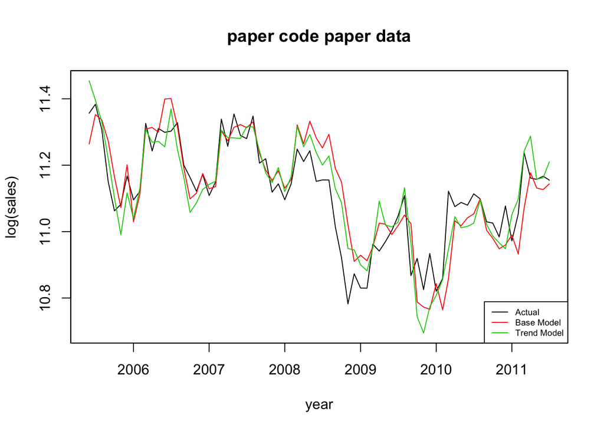

```
## [1] "paper code paper data MAE"
##   mae.base mae.trends  mae.delta
## 0.06343984 0.05667658 0.10660890
```

```r
dat <- read.csv("data/merged.csv")
getModelandEvaluation(dat, plot_title = "paper code paper data")
```

## 1.3 Paper’s code, our data

### 1.3.1 2014-2019

```
## [1] "Summary of base model"
##
## Call:
## lm(formula = dyn(y ~ lag(y, -1) + lag(y, -12)))
##
## Residuals:
##       Min        1Q    Median        3Q       Max
## -0.056864 -0.011243  0.004109  0.017806  0.042493
##
## Coefficients:
##             Estimate Std. Error t value Pr(>|t|)
## (Intercept)  2.12923    0.60807   3.502  0.00106 **
## lag(y, -1)  -0.07381    0.05181  -1.425  0.16119
## lag(y, -12)  0.89178    0.05061  17.621  < 2e-16 ***
## ---
## Signif. codes:  0 '***' 0.001 '**' 0.01 '*' 0.05 '.' 0.1 ' ' 1
##
## Residual standard error: 0.02472 on 45 degrees of freedom
##   (12 observations deleted due to missingness)
## Multiple R-squared:  0.8912, Adjusted R-squared:  0.8863
## F-statistic: 184.3 on 2 and 45 DF,  p-value: < 2.2e-16
##
## [1] "Summary of trend model"
##
## Call:
## lm(formula = dyn(y ~ lag(y, -1) + lag(y, -12) + suvs + insurance),
##     data = data)
##
## Residuals:
##       Min        1Q    Median        3Q       Max
## -0.050471 -0.011631  0.003964  0.014242  0.055628
##
## Coefficients:
##               Estimate Std. Error t value Pr(>|t|)
## (Intercept)  1.3107081  0.7257228   1.806   0.0779 .
## lag(y, -1)  -0.0642127  0.0515807  -1.245   0.2199
## lag(y, -12)  0.9563745  0.0584994  16.348   <2e-16 ***
## suvs         0.0012462  0.0009645   1.292   0.2033
## insurance   -0.0016657  0.0008877  -1.876   0.0674 .
## ---
## Signif. codes:  0 '***' 0.001 '**' 0.01 '*' 0.05 '.' 0.1 ' ' 1
##
## Residual standard error: 0.02409 on 43 degrees of freedom
##   (12 observations deleted due to missingness)
## Multiple R-squared:  0.9013, Adjusted R-squared:  0.8921
## F-statistic: 98.12 on 4 and 43 DF,  p-value: < 2.2e-16
```

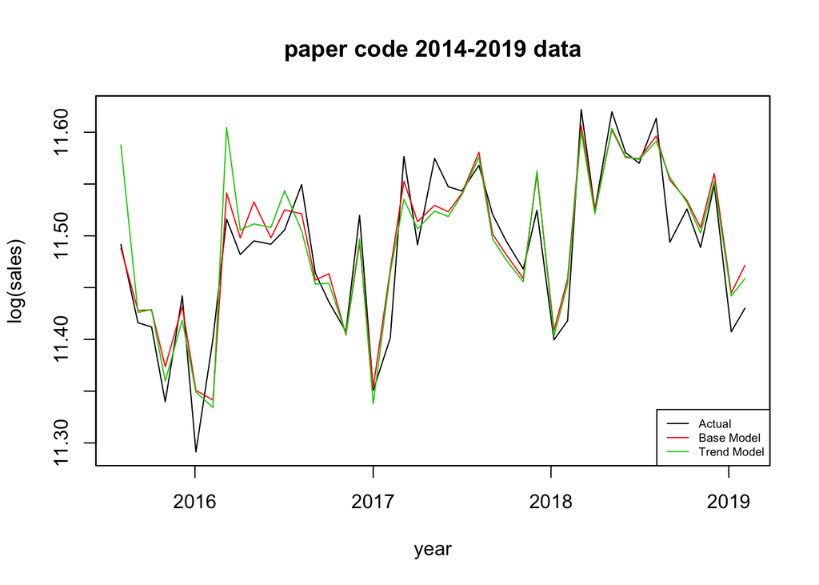

```
## [1] "paper code 2014-2019 data MAE"
##    mae.base  mae.trends   mae.delta
##  0.02215164  0.02663886 -0.20256814
```

```r
merged1419 <- read.csv("data/merged_14_19.csv")
getModelandEvaluation(merged1419, plot_title = "paper code 2014-2019 data")
```